# Additional Topics for Factorial and Fractional Factorial Designs

# Example 9.1

The syrup loss experiment of Table 9.1 investigates how nozzle design, the filling speed, and the operating pressure affect the amount of syrup lost while filling containers. Each factor is investigated at three levels using a $3^3$ design. Note that we want to treat `Speed` and `Pressure` as factors for the ANOVA model.

```r
model <- aov(SyrupLoss ~ NozzleType * factor(Speed) * factor(Pressure), data=Table9.1)
print(summary(model))
#                                           Df Sum Sq Mean Sq F value
# NozzleType                                 2    994     497   1.165
# factor(Speed)                              2  61190   30595  71.735
# factor(Pressure)                           2  69105   34553  81.014
# NozzleType:factor(Speed)                   4   6301    1575   3.693
# NozzleType:factor(Pressure)                4   7514    1878   4.404
# factor(Speed):factor(Pressure)             4  12854    3214   7.535
# NozzleType:factor(Speed):factor(Pressure)  8   4629     579   1.357
# Residuals                                 27  11516     426
#                                             Pr(>F)
# NozzleType                                0.327102
# factor(Speed)                             1.57e-11 ***
# factor(Pressure)                          3.89e-12 ***
# NozzleType:factor(Speed)                  0.015950 *
# NozzleType:factor(Pressure)               0.007187 **
# factor(Speed):factor(Pressure)            0.000327 ***
# NozzleType:factor(Speed):factor(Pressure) 0.259496
# Residuals
# ---
# Signif. codes:  0 '***' 0.001 '**' 0.01 '*' 0.05 '.' 0.1 ' ' 1
```

Next we’ll fit regression models for each nozzle type to fit a contour plot for each nozzle type.

```r
code.speed <- function(x){
    (x - 120) / (140 - 120)
}

code.pressure <- function(x){
    (x - 15) / (20 - 15)
}

df.reg <- data.frame(
    'NozzleType'=Table9.1$NozzleType,
    'Speed'=code.speed(Table9.1$Speed),
    'Pressure'=code.pressure(Table9.1$Pressure),
    'SyrupLoss'=Table9.1$SyrupLoss
)

model1 <- lm(SyrupLoss ~ Speed * Pressure + I(Speed^2) + I(Pressure^2), data=df.reg[df.reg$NozzleType == 1,])
model2 <- lm(SyrupLoss ~ Speed * Pressure + I(Speed^2) + I(Pressure^2), data=df.reg[df.reg$NozzleType == 2,])
model3 <- lm(SyrupLoss ~ Speed * Pressure + I(Speed^2) + I(Pressure^2), data=df.reg[df.reg$NozzleType == 3,])

print(coef(model1))
#    (Intercept)          Speed       Pressure     I(Speed^2)  I(Pressure^2)
#       22.05556        3.50000       16.33333       51.66667      -71.83333
# Speed:Pressure
#        2.87500
print(coef(model2))
#    (Intercept)          Speed       Pressure     I(Speed^2)  I(Pressure^2)
#     -17.833333      -5.083333     -12.250000      84.250000     -60.250000
# Speed:Pressure
#      -0.750000
print(coef(model3))
#    (Intercept)          Speed       Pressure     I(Speed^2)  I(Pressure^2)
#      15.111111      20.333333       5.916667      75.833333     -94.916667
# Speed:Pressure
#      10.500000
```

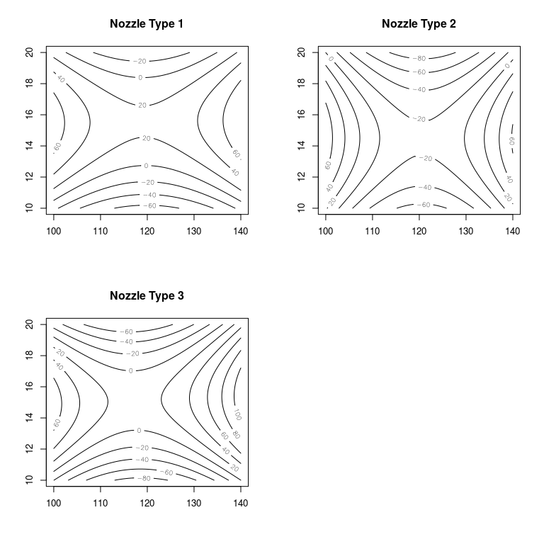

```r
x <- seq(from=100, to=140, length.out=100)
y <- seq(from=10, to=20, length.out=100)
df0 <- expand.grid('Speed'=code.speed(x), 'Pressure'=code.pressure(y))

z1 <- matrix(predict(model1, df0), ncol=100)
z2 <- matrix(predict(model2, df0), ncol=100)
z3 <- matrix(predict(model3, df0), ncol=100)

par(mfrow=c(2,2))
contour(x, y, z1, main='Nozzle Type 1')
contour(x, y, z2, main='Nozzle Type 2')
contour(x, y, z3, main='Nozzle Type 3')
plot.new()  # This just uses up the last cell.
```

# Example 9.2

This example illustrates the design of a $3^2$ in three blocks (aliasing the $AB^2$ effect with blocks).

```r
model <- aov(Response ~ Error(Block) + A + B + A:B, data=Example9.2)
print(summary(model))
#
# Error: Block
#     Df Sum Sq Mean Sq
# A:B  2  10.89   5.444
#
# Error: Within
#     Df Sum Sq Mean Sq
# A    2 131.56   65.78
# B    2   0.22    0.11
# A:B  2   2.89    1.44
```

# Figure 9.10

Constructing correlation plots is easiest to do using the `corrplot` package (Wei et al. 2017). Here, I construct the correlation plot for the $2^{6-2}$ Resolution IV design of Figure 9.10:

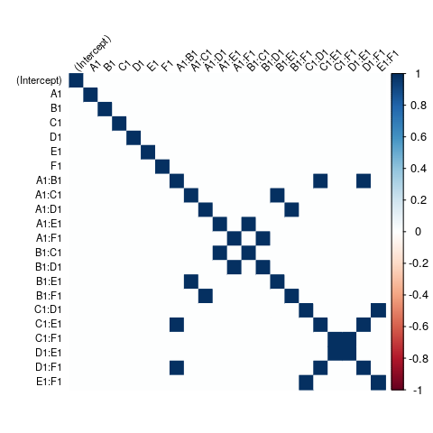

```r
library(FrF2)
library(corrplot)
# corrplot 0.84 loaded

X.d <- FrF2(nfactors=6, nruns=16)
X.m <- model.matrix(~.*., data=X.d)
X.corr <- t(X.m) %*% X.m / 16
corrplot(X.corr, method='color', tl.col="black", tl.srt=45, tl.cex=0.7)
```

# Example 9.3 - The Spin Coating Experiment

Recall the spin coating experiment from Section 8.7.2. Again we use stepwise regression.

```r
model <- p.stepwise(
    lm(Thickness ~ 1, Table9.24),
    ~ (A + B + C + D + E + F)^2,
    alpha.to.enter=0.20,
    alpha.to.leave=0.20
)
# Beginning Stepwise Regression
#   Model: Thickness ~ 1
# Steps:
#   Adding A at p=0.0001. Model sigma=86.672413, R^2=66.0%, Adj-R^2=63.5%
#   Adding B at p=0.0134. Model sigma=70.474900, R^2=79.1%, Adj-R^2=75.9%
#   Adding C at p=0.0466. Model sigma=61.777996, R^2=85.2%, Adj-R^2=81.5%
#   Adding E at p=0.1735. Model sigma=59.085647, R^2=87.6%, Adj-R^2=83.1%
#   Adding C:E at p=0.0022. Model sigma=37.975979, R^2=95.3%, Adj-R^2=93.0%
#   Adding B:E at p=0.1133. Model sigma=34.555511, R^2=96.5%, Adj-R^2=94.2%
print(summary(model))
#
# Call:
# lm.default(formula = Thickness ~ A + B + C + E + C:E + B:E, data = Table9.24)
#
# Residuals:
#     Min      1Q  Median      3Q     Max
# -63.875  -5.375   3.625  16.625  45.125
#
# Coefficients:
#             Estimate Std. Error t value Pr(>|t|)
# (Intercept) 4462.875      8.639 516.604  < 2e-16 ***
# A             85.500     10.580   8.081 2.04e-05 ***
# B            -77.750     10.580  -7.348 4.33e-05 ***
# C            -25.500      9.975  -2.556  0.03087 *
# E             21.500      8.639   2.489  0.03449 *
# C:E           54.750     12.217   4.481  0.00153 **
# B:E          -17.500      9.975  -1.754  0.11327
# ---
# Signif. codes:  0 '***' 0.001 '**' 0.01 '*' 0.05 '.' 0.1 ' ' 1
#
# Residual standard error: 34.56 on 9 degrees of freedom
# Multiple R-squared:  0.9652,  Adjusted R-squared:  0.942
# F-statistic: 41.63 on 6 and 9 DF,  p-value: 4.602e-06
print(anova(model))
# Analysis of Variance Table
#
# Response: Thickness
#           Df Sum Sq Mean Sq  F value    Pr(>F)
# A          1 203852  203852 170.7186 3.718e-07 ***
# B          1  40602   40602  34.0029 0.0002495 ***
# C          1  18769   18769  15.7183 0.0032812 **
# E          1   7396    7396   6.1939 0.0344927 *
# C:E        1  23980   23980  20.0828 0.0015294 **
# B:E        1   3675    3675   3.0777 0.1132691
# Residuals  9  10747    1194
# ---
# Signif. codes:  0 '***' 0.001 '**' 0.01 '*' 0.05 '.' 0.1 ' ' 1
```

# Example 9.4

At present there’s no easy way to construct $I$-optimal designs with blocks using R. We will construct an I-optimal design for 6 factors at levels $(-1, 0, 1)$. The design from the text has balanced blocks with three runs in each block, but the `AlgDesign` package does not support this constraint for $I$-optimal designs.

```r
library(AlgDesign)

candidate.list <- expand.grid(
    'A'=c(-1, 0, 1),
    'B'=c(-1, 0, 1),
    'C'=c(-1, 0, 1),
    'D'=c(-1, 0, 1),
    'E'=c(-1, 0, 1),
    'F'=c(-1, 0, 1)
)

opt.i <- optFederov(~A+B+C+D+E+F, data=candidate.list, nTrials=12, criterion='I', approximate=FALSE, nRepeats=1000)
```

The optimal design discovered has I-criterion 5 and the following layout.

|  | A | B | C | D | E | F |
| --- | --- | --- | --- | --- | --- | --- |
| 9 | 1 | 1 | -1 | -1 | -1 | -1 |
| 21 | 1 | -1 | 1 | -1 | -1 | -1 |
| 79 | -1 | 1 | 1 | 1 | -1 | -1 |
| 163 | -1 | -1 | -1 | -1 | 1 | -1 |
| 217 | -1 | -1 | -1 | 1 | 1 | -1 |
| 243 | 1 | 1 | 1 | 1 | 1 | -1 |
| 505 | -1 | -1 | 1 | -1 | -1 | 1 |
| 543 | 1 | -1 | -1 | 1 | -1 | 1 |
| 547 | -1 | 1 | -1 | 1 | -1 | 1 |
| 657 | 1 | 1 | -1 | -1 | 1 | 1 |
| 673 | -1 | 1 | 1 | -1 | 1 | 1 |
| 723 | 1 | -1 | 1 | 1 | 1 | 1 |

Compare this to the design in Table 9.36. The value of the I-criterion for this design is as follows:

```r
eval.design(~ A + B + C + D + E + F, design=Table9.36, X=candidate.list)$I
# [1] 6.027472
```

# References

Wei, Taiyun, Viliam Simko, Michael Levy, Yihui Xie, Yan Jin, and Jeff Zemela. 2017. *Corrplot: Visualization of a Correlation Matrix*. https://cran.r-project.org/package=corrplot.